# Bellabeat FitBit Tracker

Jumoke Ajakaiye

5/12/2021

# Bellabeat Introduction

Urška Sršen is Bellabeat’s co-founder and Chief Creative Officer. Sando Mur is a Mathematician and Bellabeat’s co-founder, the key member of the Bellabeat executive team. Bellabeat, a high-tech company that manufactures health-focused smart products for women. Bellabeat is a successful small company; collecting data on activity, sleep, stress, and reproductive health has allowed Bellabeat to empower women with knowledge about their health and habits. Since it started in 2013, Bellabeat has grown rapidly and quickly positioned itself as a tech-driven wellness company for women.

## Business Task

This report aims to analyze smart device usage data to gain insight into consumers’ use of non-Bellabeat smart devices. Then I would apply these insights to one of the Bellabeat products in my analysis.

## Analysis Questions

- 1.What are some trends in smart device usage?
- 2.How could these trends apply to Bellabeat customers?
- 3.How could these trends help influence Bellabeat marketing strategy?

**Notes:** In this analysis, I collected two datasets to analyze and gain insight into consumers’ usage of these smart devices. The first dataset is called FitBit Fitness Tracker Data, and the second dataset is called Sleep Pattern.

## Setting up my environment

**Notes:** I’m setting up my R environment by loading the ‘tidyverse’ and ‘lubridate’ packages.

```r
install.packages("tidyverse",repos = "http://cran.us.r-project.org")
library(tidyverse)
```

```r
library(ggplot2)
library(lubridate)
library(janitor)
library(readr)
```

## Loading the Data

The first dataset is Fitbit Fitness Tracker Data has 18 CSV files. I’m focusing on loading daily_activity to analyze it. The second dataset is Sleep Pattern which has 1 CSV file called sleep_analysis to compare with the information I downloaded from the first dataset.

```r
daily_activity <- read.csv("daily_activity.csv")
```

Once the dataframe file is uploaded, I’ll clean the CSV columns to make it easier for this data analysis process.

```r
daily_activity <- daily_activity %>%
  janitor::clean_names()
```

Now I’ll load the second dataset below as a dataframe:

```r
sleep_analysis <- read.csv("sleep_analysis.csv")
```

## Exploring the Two Dataframes Tables

Take a look at daily_activity table

```r
head(daily_activity)
```

```
##           id activity_date total_steps total_distance tracker_distance
## 1 1503960366     4/12/2016       13162           8.50             8.50
## 2 1503960366     4/13/2016       10735           6.97             6.97
## 3 1503960366     4/14/2016       10460           6.74             6.74
## 4 1503960366     4/15/2016        9762           6.28             6.28
## 5 1503960366     4/16/2016       12669           8.16             8.16
## 6 1503960366     4/17/2016        9705           6.48             6.48
##   logged_activities_distance very_active_distance moderately_active_distance
## 1                          0                 1.88                       0.55
## 2                          0                 1.57                       0.69
## 3                          0                 2.44                       0.40
## 4                          0                 2.14                       1.26
## 5                          0                 2.71                       0.41
## 6                          0                 3.19                       0.78
##   light_active_distance sedentary_active_distance very_active_minutes
## 1                  6.06                         0                  25
## 2                  4.71                         0                  21
## 3                  3.91                         0                  30
## 4                  2.83                         0                  29
## 5                  5.04                         0                  36
## 6                  2.51                         0                  38
##   fairly_active_minutes lightly_active_minutes sedentary_minutes calories
## 1                    13                    328               728     1985
## 2                    19                    217               776     1797
## 3                    11                    181              1218     1776
## 4                    34                    209               726     1745
## 5                    10                    221               773     1863
## 6                    20                    164               539     1728
```

Take a look at all the columns in daily_activity data.

```r
colnames(daily_activity)
```

```
##  [1] "id"                         "activity_date"
##  [3] "total_steps"                "total_distance"
##  [5] "tracker_distance"           "logged_activities_distance"
##  [7] "very_active_distance"       "moderately_active_distance"
##  [9] "light_active_distance"      "sedentary_active_distance"
## [11] "very_active_minutes"        "fairly_active_minutes"
## [13] "lightly_active_minutes"     "sedentary_minutes"
## [15] "calories"
```

Take a look at the sleep_analysis table.

```r
head(sleep_analysis)
```

```
##   age gender meals_day physical_illness screen_time bluelight_filter
## 1  22   Male       two               no           2              yes
## 2  22 Female     three               no           4               no
## 3  23   Male     three               no           4               no
## 4  23 Female       two               no           2               no
## 5  22   Male     three               no           5              yes
## 6  22   Male       two               no           3              yes
##   sleep_direction  exercise smoke_drink            beverage sleep_time
## 1            west sometimes          no                 Tea          7
## 2           south        no          no              Coffee          8
## 3           south        no          no                 Tea          8
## 4            east sometimes          no              Coffee          7
## 5            east sometimes         yes Tea and Coffee both          6
## 6            west sometimes          no                 Tea          7
```

Take a look at all the columns in sleep_analysis data.

```r
colnames(sleep_analysis)
```

```
##  [1] "age"              "gender"           "meals_day"        "physical_illness"
##  [5] "screen_time"      "bluelight_filter" "sleep_direction"  "exercise"
##  [9] "smoke_drink"      "beverage"         "sleep_time"
```

## Understanding Some Summary Statistics

How many unique participants are there in each dataframe?

```r
n_distinct(daily_activity$id)
```

```
## [1] 33
```

```r
n_distinct(sleep_analysis$age)
```

```
## [1] 10
```

How many observations are there in each dataframe?

```r
nrow(daily_activity)
```

```
## [1] 940
```

```r
nrow(sleep_analysis)
```

```
## [1] 46
```

A quick summary of statistics we’d want to know about each dataframe.

daily_activity summary dataframe:

```r
daily_activity %>%
  select(total_steps,
         total_distance,
         very_active_minutes,
         lightly_active_minutes,
         fairly_active_minutes,
         sedentary_minutes) %>%
  summary()
```

```
##   total_steps    total_distance   very_active_minutes lightly_active_minutes
##  Min.   :    0   Min.   : 0.000   Min.   :  0.00      Min.   :  0.0
##  1st Qu.: 3790   1st Qu.: 2.620   1st Qu.:  0.00      1st Qu.:127.0
##  Median : 7406   Median : 5.245   Median :  4.00      Median :199.0
##  Mean   : 7638   Mean   : 5.490   Mean   : 21.16      Mean   :192.8
##  3rd Qu.:10727   3rd Qu.: 7.713   3rd Qu.: 32.00      3rd Qu.:264.0
##  Max.   :36019   Max.   :28.030   Max.   :210.00      Max.   :518.0
##  fairly_active_minutes sedentary_minutes
##  Min.   :  0.00        Min.   :   0.0
##  1st Qu.:  0.00        1st Qu.: 729.8
##  Median :  6.00        Median :1057.5
##  Mean   : 13.56        Mean   : 991.2
##  3rd Qu.: 19.00        3rd Qu.:1229.5
##  Max.   :143.00        Max.   :1440.0
```

sleep_analysis summary dataframe:

```r
sleep_analysis %>%
  select(age,
         sleep_time,
         screen_time) %>%
  summary()
```

```
##       age          sleep_time     screen_time
##  Min.   :20.00   Min.   :2.000   Min.   :1.00
##  1st Qu.:22.00   1st Qu.:6.250   1st Qu.:3.00
##  Median :23.00   Median :7.000   Median :4.00
##  Mean   :24.76   Mean   :6.804   Mean   :3.87
##  3rd Qu.:24.00   3rd Qu.:8.000   3rd Qu.:5.00
##  Max.   :59.00   Max.   :9.000   Max.   :5.00
```

# Data Analysis

The daily_activity dataframe has total_steps and total_distance. I’ll create a new dataframe including total active minutes to compare with sedentary_minutes, total_steps, and total_distance.

```r
daily_activity2 <- daily_activity %>%
  select(id,
         total_steps,
         total_distance,
         very_active_minutes,
         lightly_active_minutes,
         fairly_active_minutes,
         sedentary_minutes) %>%
  mutate(total_activemins = very_active_minutes + lightly_active_minutes +
           fairly_active_minutes)
```

As I did the summary above for daily_activity, then I’ll execute a summary for daily_activity2 below:

```r
daily_activity2 %>%
  select(total_steps,
         total_steps,
         total_distance,
         very_active_minutes,
         lightly_active_minutes,
         fairly_active_minutes,
         sedentary_minutes,
         total_activemins) %>%
  summary()
```

```
##   total_steps    total_distance   very_active_minutes lightly_active_minutes
##  Min.   :    0   Min.   : 0.000   Min.   :  0.00      Min.   :  0.0
##  1st Qu.: 3790   1st Qu.: 2.620   1st Qu.:  0.00      1st Qu.:127.0
##  Median : 7406   Median : 5.245   Median :  4.00      Median :199.0
##  Mean   : 7638   Mean   : 5.490   Mean   : 21.16      Mean   :192.8
##  3rd Qu.:10727   3rd Qu.: 7.713   3rd Qu.: 32.00      3rd Qu.:264.0
##  Max.   :36019   Max.   :28.030   Max.   :210.00      Max.   :518.0
##  fairly_active_minutes sedentary_minutes total_activemins
##  Min.   :  0.00        Min.   :   0.0    Min.   :  0.0
##  1st Qu.:  0.00        1st Qu.: 729.8    1st Qu.:146.8
##  Median :  6.00        Median :1057.5    Median :247.0
##  Mean   : 13.56        Mean   : 991.2    Mean   :227.5
##  3rd Qu.: 19.00        3rd Qu.:1229.5    3rd Qu.:317.2
##  Max.   :143.00        Max.   :1440.0    Max.   :552.0
```

This dataframe is plotted using ggplot2 and illustrates the total of steps vs. total_activemins.

This visual reveals that users are usually **active between 2.5 hours to 5.8 hours**, and the **incremental steps are between 0 to 20,000 a day.** Bellabeat should market the application to improve upon the users increasing active hours a day or consistently staying in the same range.

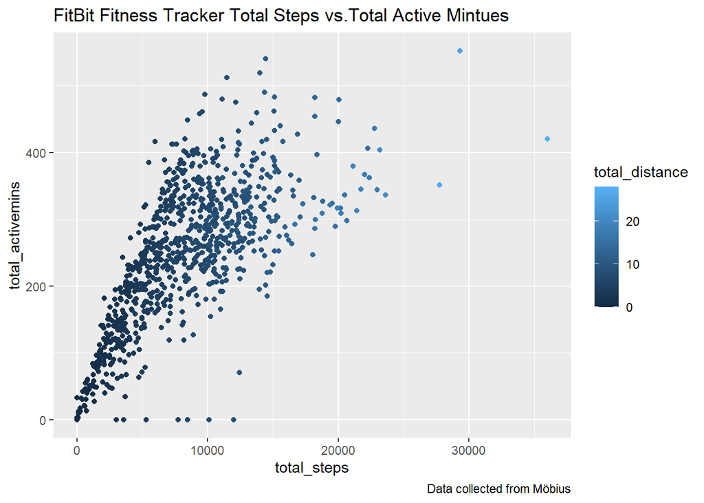

```r
ggplot(data = daily_activity2)+
  geom_point(mapping = aes(x = total_steps, y = total_activemins, color = total_distance )) +
  labs(title = "FitBit Fitness Tracker Total Steps vs.Total Active Mintues", caption = "Data collected from Möbius")
```

What’s the relationship between total_activemins taken in a day and sedentary_minutes?

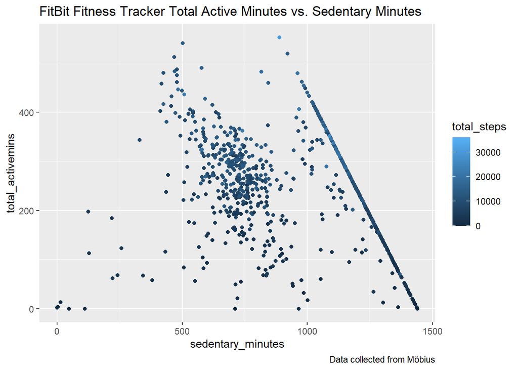

```r
ggplot(data = daily_activity2) +
  geom_point(mapping = aes(x = sedentary_minutes, y =total_activemins, color = total_steps))+
  labs(title = "FitBit Fitness Tracker Total Active Minutes vs. Sedentary Minutes", caption = "Data collected from Möbius")
```

What’s the relationship between screen_time and sleep_time in a day? Would there be any unexpected trends?

This unexpected trend in this graphic shows males start with fewer hours spent on a smart device, then gradually increased then decreased again. Females have a steady line then increased screen_time to 5 hours a day. The visual gives insight that females are usually sleeping around 7 hours a day. This information provides the marketing team with ways to improve the application that tracks the user sleep patterns.

Even though the company’s health-focused products market to females, the marketing team can propose a campaign to consider in the future to branch out and market the males.

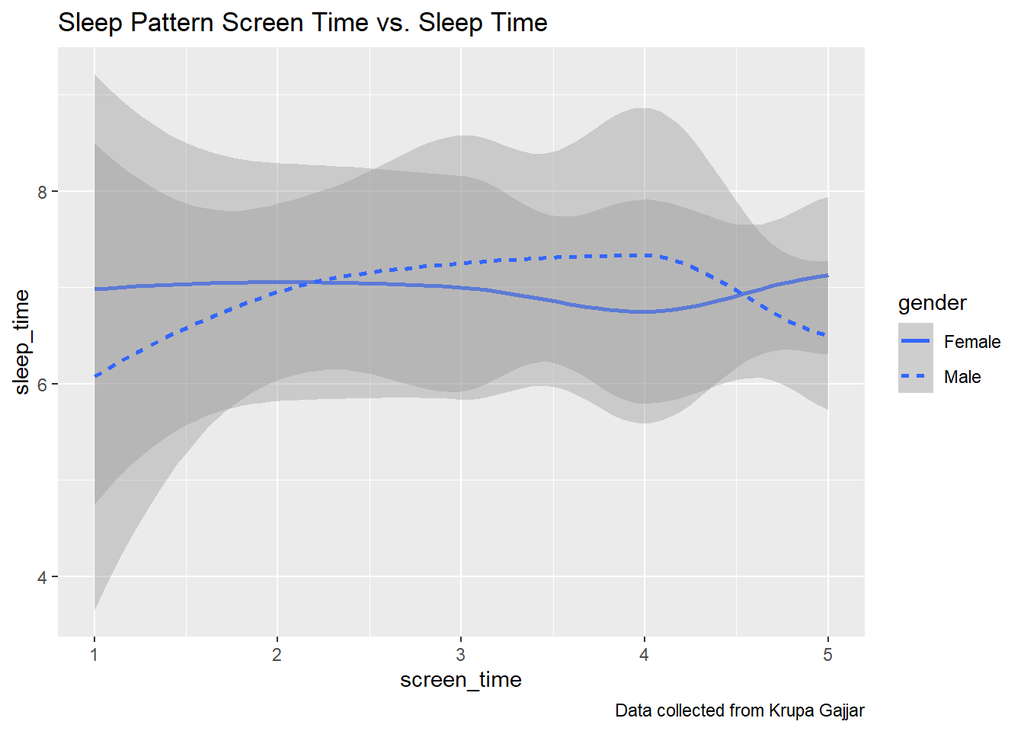

Let’s look at the relationship between the exercise vs. screen_time.

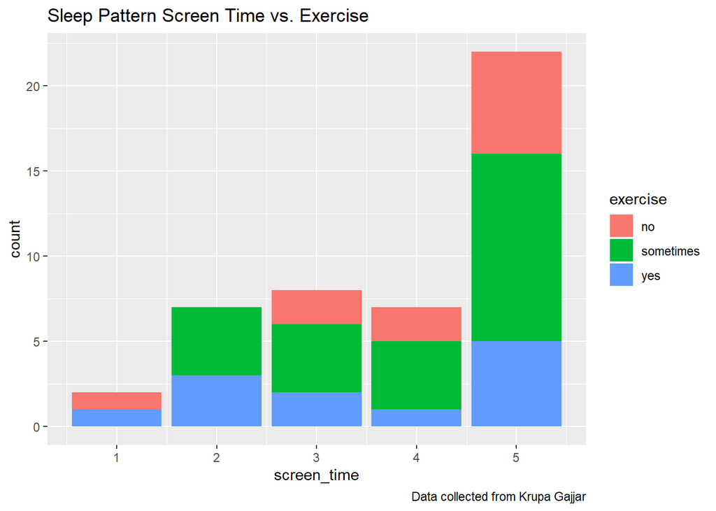

```r
ggplot(data = sleep_analysis)+
  geom_bar(mapping = aes(x = screen_time, fill = exercise))+
  labs(title = "Sleep Pattern Screen Time vs. Exercise", caption = "Data collected from Krupa Gajjar")
```

Let’s check the connection between meals_day, screen_time, and exercise. The visual wrap exercises data and gives an insight into how many meals_day and screen_time a user does in a day.

Bellabeat strategy should focus on marketing their Bellabeat app that provides users with health data related to their activity, sleep, stress, menstrual cycle, and mindfulness habits. This marketing strategy will help users track their meals a day, exercise, and monitor the time spent on their phones to make healthy decisions.

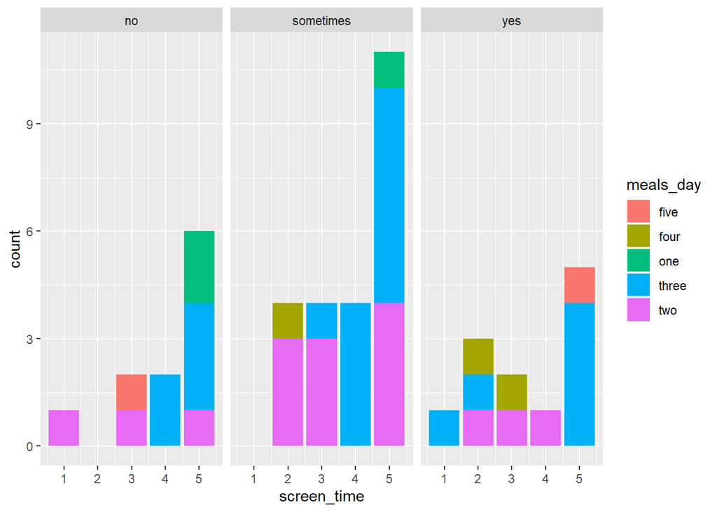

```r
ggplot(data = sleep_analysis)+
  geom_bar(mapping = aes(x = screen_time, fill = meals_day))+ facet_wrap(~exercise)
```

```r
  labs(title = "Sleep Pattern Screen Time vs. Meals Day",
       caption = "Data collected from Krupa Gajjar")
```

```
## $title
## [1] "Sleep Pattern Screen Time vs. Meals Day"
##
## $caption
## [1] "Data collected from Krupa Gajjar"
##
## attr(,"class")
## [1] "labels"
```

# Summary of my analysis

The company should take these insights and trends and use the findings to promote the Bellabeat app since the data shows users are using their smart devices on average 4 hours a day. With users being active 4 hours a day and sedentary for 17 hours, the company should advertise features that focus more on the user to increase their daily routine in being more mindful of working out more than being inactive.

This project gathered the daily_activity dataset from FitBit Fitness Tracker and the sleep_analysis dataset from Sleep Pattern. I will continue to analyze other datasets from FitBit Fitness Tracker to retrieve more insights of users using non-Bellabeat smart devices.

**I’m open to receiving feedback on my analysis. Thank you.**

# Resources

For more information, check out this link to review the orginial dataset of FitBit Fitness Tracker Data [here](https://www.kaggle.com/arashnic/fitbit) and this link for Sleep Analysis [here](https://www.kaggle.com/krupa1999/sleep-pattern).